# Lab 2: non-linear models

Chris Troeger

January 20, 2022

# Generalized (non) linear models in R

### Create data from homework 1

```
##     admin2 admin2id village_id longitude  latitude year_baseline
## 1: Banfora      826        521 -4.605542 10.454400          1997
## 2: Banfora      826        522 -4.888910 10.523700          1996
## 3: Banfora      826        523 -4.834913  9.870183          1997
## 4: Banfora      826        524 -4.853712 10.334840          1995
## 5: Banfora      826        525 -4.749786 10.774750          1996
## 6: Banfora      826        526 -4.745618 10.290300          1997
##    nodule_positive_base nodule_tested_base nodule_prev_base year_eval
## 1:                   93                104        0.8942308      2004
## 2:                   93                 97        0.9587629      2004
## 3:                   83                103        0.8058252      2005
## 4:                   54                 96        0.5625000      2004
## 5:                   92                 97        0.9484536      2004
## 6:                   55                 95        0.5789474      2005
##    nodule_eval_tested nodule_eval_positive nodule_eval_prev ov16_eval_tested
```

[output cut: 27 more lines]

## Let’s think about how we would model different variables from this dataset.

A big part of the choice rests on the properties of the response (Y) variable. A linear model assumes that the response can be values $-\infty$ to $\infty$.

For this class, we are going to focus on two types of non-linear responses:

**Binary (must be $0 <= y <= 1$)**

- Individual level: binary (0/1)
- Population level: prevalence/proportion (values 0-1)

**Count (must be $0 <= y$ to $\infty$)**

- Individual level: events (non-negative integers)
- Population level: rates (non-negative)

Both of these has a “family” in the $glm()$ function in R.

Let’s think about the the data in homework 1. I have already prepped these data (see the code in the .Rmd file). I am going to do some pretty forced regressions as examples.

### Binary: vector control

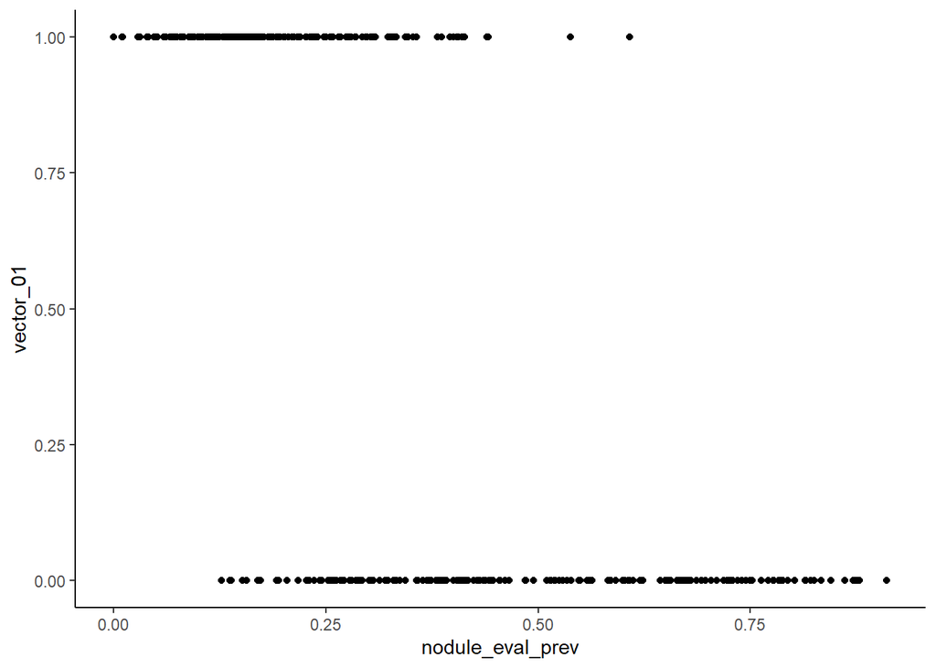

Fitting a linear model to these data would be bad. That’s because vector_01 can’t take any values except 0 or 1. A linear model will

- be biased
- have massive heteroskedasticity
- produce impossible predictions
- be an incorrect functional form

```r
mod1 <- glm(vector_01 ~ nodule_eval_prev, data = dt)
mod2 <- glm(vector_01 ~ nodule_eval_prev, data = dt, family = "binomial")

# summary(mod1)
# summary(mod2)
```

Recall that the coefficients from a binomial regression is not in linear space. With the help of some algebra, the coefficients represent the log(odds) of the outcome given a one unit change in the predictor.

```r
print(paste0("The odds that vector control is 1 when nodule prevalence at baseline is 1 is ", round(exp(coef(mod2)[2]), 6), " (compared to when prevalence is 0)."))
```

```
## [1] "The odds that vector control is 1 when nodule prevalence at baseline is 1 is 1e-06 (compared to when prevalence is 0)."
```

Now for predictions. Note that we need to find the inverse logit of the predictions from the second model. That’s because the predictions will be in logit space.

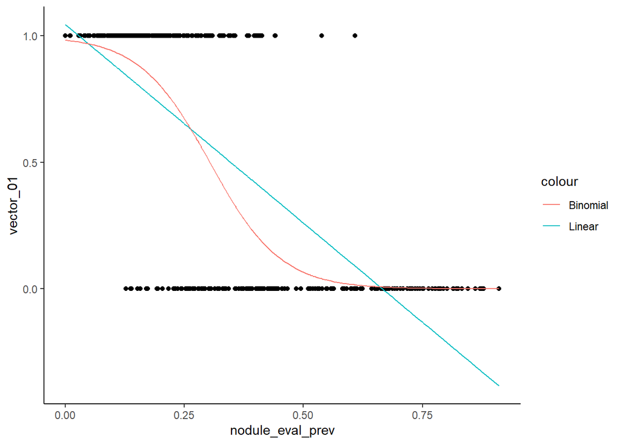

```r
dt$pred_mod1 <- predict(mod1, newdata = dt)
dt$pred_mod2 <- inv.logit(predict(mod2, newdata = dt)) # note inverse logit

ggplot(dt, aes(x = nodule_eval_prev, y = vector_01)) + geom_point() + theme_classic() +
  geom_line(aes(y = pred_mod1, col = "Linear")) +
  geom_line(aes(y = pred_mod2, col = "Binomial"))
```

### Population summary binomial: oocyte prevalence at evaluation

Binomial models can also be used for modeling prevalence (population) outcomes. That is because the model interprets values bound between 0 and 1 as the number of successes ($k$) among $n$ Bernoulli trials (think of counting heads from total coin flips).

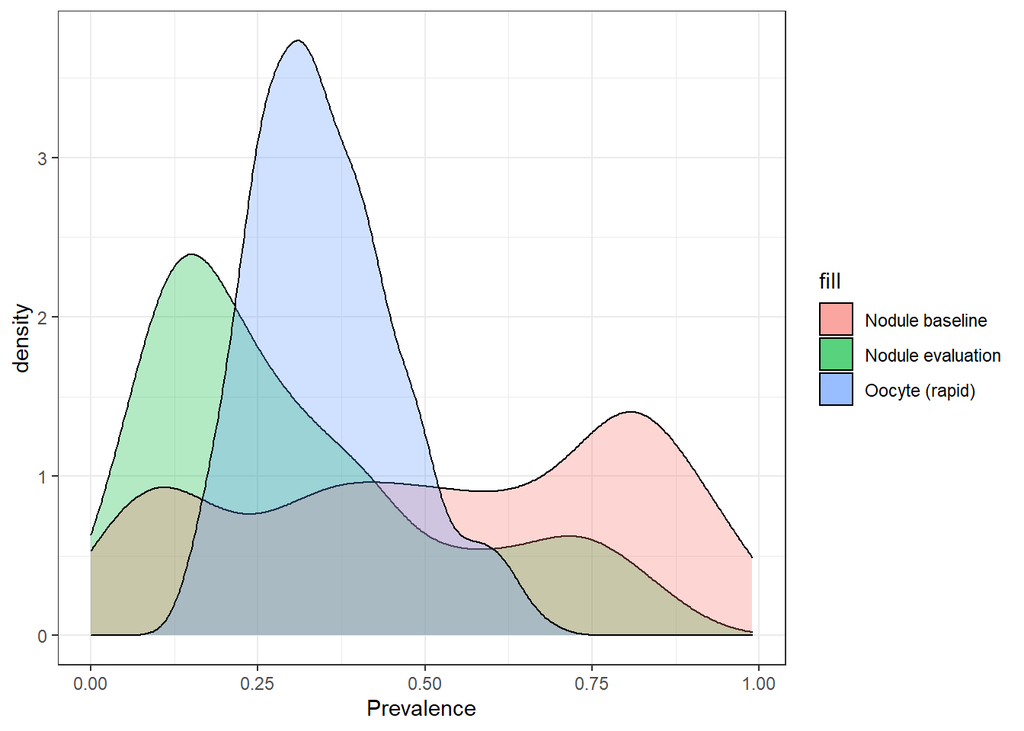

```r
ggplot(dt) +
  geom_density(aes(x = nodule_eval_prev, fill = "Nodule evaluation"), alpha = 0.3) +
  geom_density(aes(x = nodule_prev_base, fill = "Nodule baseline"), alpha = 0.3) +
  geom_density(aes(x = ov16_eval_prev, fill = "Oocyte (rapid)"), alpha = 0.3) +
  theme_bw() + xlab("Prevalence")
```

The prevalence of onchocerciasis must be $0 <= P_o <= 1$. We can use a binomial model.

```r
# Let's create a linear and binomial model of final prevalence
ep_lmod <- glm(ov16_eval_prev ~ vector_01 + mda_rounds, data = dt)
ep_bmod <- glm(ov16_eval_prev ~ vector_01 + mda_rounds, data = dt, family = "binomial")
```

What was that? Was it important? Kind of.

```r
ep_bmod2 <- glm(ov16_eval_prev ~ vector_01 + mda_rounds, data = dt, family = binomial(link = "log"))
summary(ep_lmod)
```

```
##
## Call:
## glm(formula = ov16_eval_prev ~ vector_01 + mda_rounds, data = dt)
##
## Deviance Residuals:
##       Min         1Q     Median         3Q        Max
## -0.267795  -0.045583  -0.001534   0.041905   0.267046
##
## Coefficients:
##              Estimate Std. Error t value Pr(>|t|)
## (Intercept)  0.497795   0.009170   54.29   <2e-16 ***
## vector_01   -0.084428   0.008347  -10.12   <2e-16 ***
## mda_rounds  -0.029731   0.002116  -14.05   <2e-16 ***
## ---
## Signif. codes:  0 '***' 0.001 '**' 0.01 '*' 0.05 '.' 0.1 ' ' 1
##
## (Dispersion parameter for gaussian family taken to be 0.006017854)
##
##     Null deviance: 4.0172  on 349  degrees of freedom
## Residual deviance: 2.0882  on 347  degrees of freedom
##   (191 observations deleted due to missingness)
## AIC: -791.31
##
## Number of Fisher Scoring iterations: 2
```

```r
summary(ep_bmod)
```

```
##
## Call:
## glm(formula = ov16_eval_prev ~ vector_01 + mda_rounds, family = "binomial",
##     data = dt)
##
## Deviance Residuals:
##      Min        1Q    Median        3Q       Max
## -0.55916  -0.09769  -0.00426   0.08966   0.54608
##
## Coefficients:
##              Estimate Std. Error z value Pr(>|z|)
## (Intercept)  0.009071   0.240120   0.038   0.9699
## vector_01   -0.374449   0.227054  -1.649   0.0991 .
## mda_rounds  -0.127905   0.056282  -2.273   0.0231 *
## ---
## Signif. codes:  0 '***' 0.001 '**' 0.01 '*' 0.05 '.' 0.1 ' ' 1
##
## (Dispersion parameter for binomial family taken to be 1)
##
##     Null deviance: 17.6878  on 349  degrees of freedom
## Residual deviance:  9.3052  on 347  degrees of freedom
##   (191 observations deleted due to missingness)
## AIC: 327.49
##
## Number of Fisher Scoring iterations: 4
```

```r
AIC(ep_lmod, ep_bmod)
```

```
##         df       AIC
## ep_lmod  4 -791.3146
## ep_bmod  3  327.4908
```

We need to shift our thinking of binomial models just a little bit (or at least I did). In a binomial model, we are modeling the **probability** of an outcome. In other words, we are modeling the probability that the response $y_i$ is 1 given the model:

$$P(y_i = 1 | model)$$
In a model of binary outcomes, we only observe 0 or 1, but in a model of prevalence or proportions, we see values between 0 and 1. Our interpretation of the coefficients remains the same: the change in log odds that the probability of an event is 100% (or all events in a sample are 1).

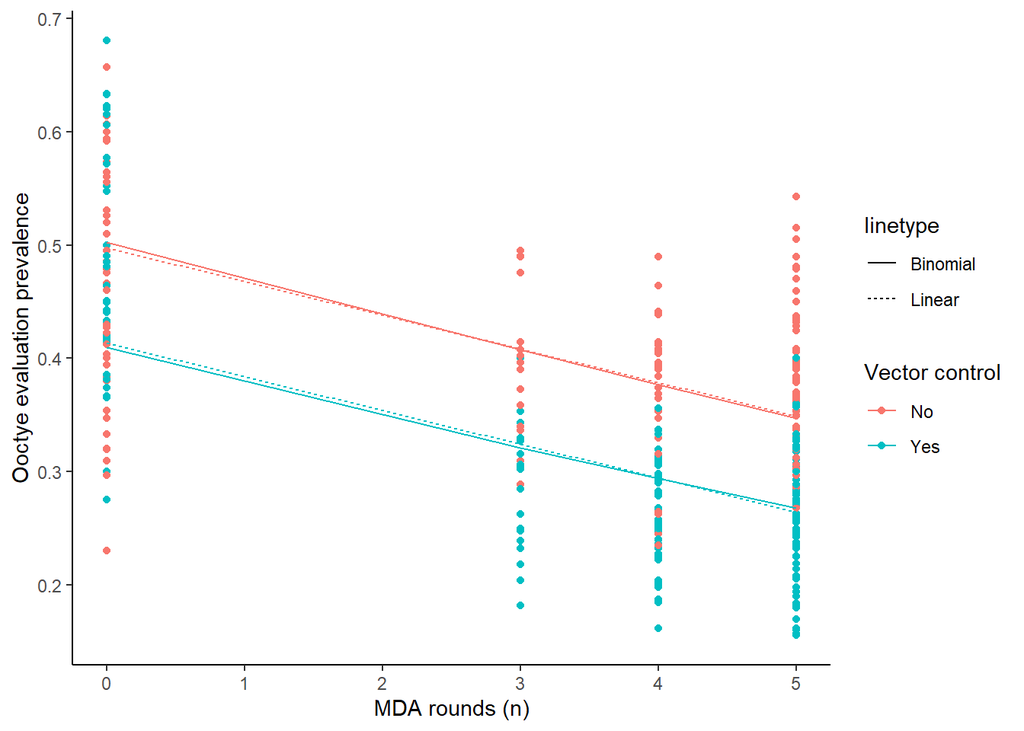

```r
dt$pred_ep_l <- predict(ep_lmod, newdata = dt)
dt$pred_ep_b <- inv.logit(predict(ep_bmod, newdata = dt))

# Make a dot plot to save ourselves some time
ggplot(dt, aes(x = mda_rounds, y = ov16_eval_prev, col = factor(vector_01))) +
  geom_point() + xlab("MDA rounds (n)") + ylab("Ooctye evaluation prevalence") +
  theme_classic() + scale_color_discrete("Vector control", labels = c("No","Yes")) +
  geom_line(data = dt, aes(y = pred_ep_l, lty = "Linear")) +
  geom_line(data = dt, aes(y = pred_ep_b, lty = "Binomial"))
```

### Count model: positive ooctye counts

For the example, let’s pretend that we had passive surveillance for onchocerciasis. People in each village that attended a health facility with symptoms were tested and the variable $ov16evalpositive$ represents the number of new cases in each village. Let’s also pretend that we know the population in each village (but I am doing that with a random generation).

```r
populations <- floor(rnorm(541, mean = 500, sd = 100))
# would be wildly unlikely, but let's make sure that no values are less than 0
range(populations)
```

```
## [1] 182 758
```

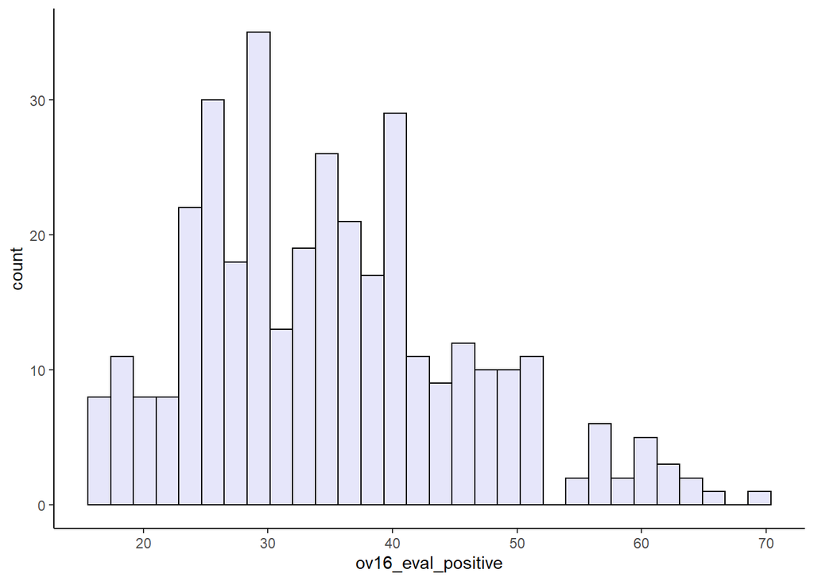

```r
# cool

dt$population <- populations
dt$oo_rate <- dt$ov16_eval_positive / dt$population

ggplot(dt, aes(x = ov16_eval_positive)) +
  geom_histogram(col = "black", fill = "lavender") +
  theme_classic()
```

This distribution looks like a Poisson distribution.

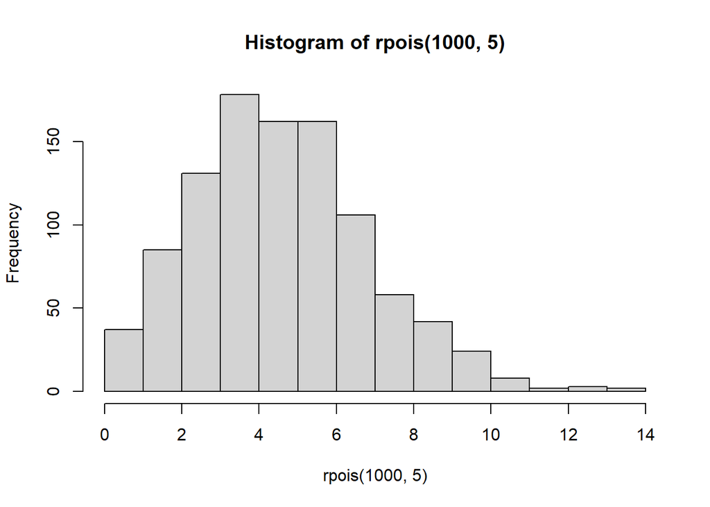

```r
hist(rpois(1000, 5))
```

In fact, we will use the Poisson distribution for modeling rates and counts.

Recall that a Poisson distribution assumes mean and variance are the same. Is that true for our data?

```r
mean(dt$ov16_eval_positive, na.rm = T)
```

```
## [1] 35.03429
```

```r
sd(dt$ov16_eval_positive, na.rm = T)^2
```

```
## [1] 117.2653
```

Nope! Unfortunately our data are **overdispersed**. We will fit a negative binomial model to our data later, too, so that we can compare.

For modeling counts, we have options to specify the model. Given we know the population, we can add that as an offset (locations with larger populations are likely to have more counts).

```r
# these are the same
mod_pois <- glm(ov16_eval_positive ~ offset(log(population)) + mda_rounds, data = dt, family = "poisson")
#mod_pois2 <- glm(ov16_eval_positive ~ mda_rounds, offset = log(population), data = dt, family = "poisson")

summary(mod_pois)
```

```
##
## Call:
## glm(formula = ov16_eval_positive ~ offset(log(population)) +
##     mda_rounds, family = "poisson", data = dt)
##
## Deviance Residuals:
##     Min       1Q   Median       3Q      Max
## -4.9069  -1.3957  -0.0223   1.2785   6.8831
##
## Coefficients:
##              Estimate Std. Error z value Pr(>|z|)
## (Intercept) -2.359108   0.015893 -148.43   <2e-16 ***
## mda_rounds  -0.089728   0.004333  -20.71   <2e-16 ***
## ---
## Signif. codes:  0 '***' 0.001 '**' 0.01 '*' 0.05 '.' 0.1 ' ' 1
##
## (Dispersion parameter for poisson family taken to be 1)
##
##     Null deviance: 1722.9  on 349  degrees of freedom
## Residual deviance: 1311.6  on 348  degrees of freedom
##   (191 observations deleted due to missingness)
## AIC: 3188.8
##
## Number of Fisher Scoring iterations: 4
```

Note that in both, we are using the count outcome as the left side of the equation and need to tell R that there should be an offset. An offset is not an estimated parameter in the model. Why is it log(population)?

$$log(\frac{ov16evalpositive}{population}) = log(ov16evalpositive) - log(population)$$

So we can simply add $log(population)$ to both sides:

$$log(ov16evalpositive_i) \sim log(population_i) + \beta_0 ...$$

It might be tempting to log transform the rate or count and then run an ordinary linear model. While there are plenty of circumstances that log-linear models might be appropriate for the outcome, in this class the better choice is probably a Poisson or negative binomial model. Let’s think about a few differences.

- A Poisson model assumes the outcome consists of non-negative integers ($0 <= y_i$ where $y_i = {0,1,2,3,4...}$)
- In contrast, a log-linear model log transforms the outcomes directly. The outcomes can be any *positive* value. Log-transformation of 0 will return -Inf because it is not a real number.
- A Poisson model makes specific assumptions about the variance (recall that in a Poisson mean = variance). In contrast, a log-normal model will assume the variance is normally distributed in log space.

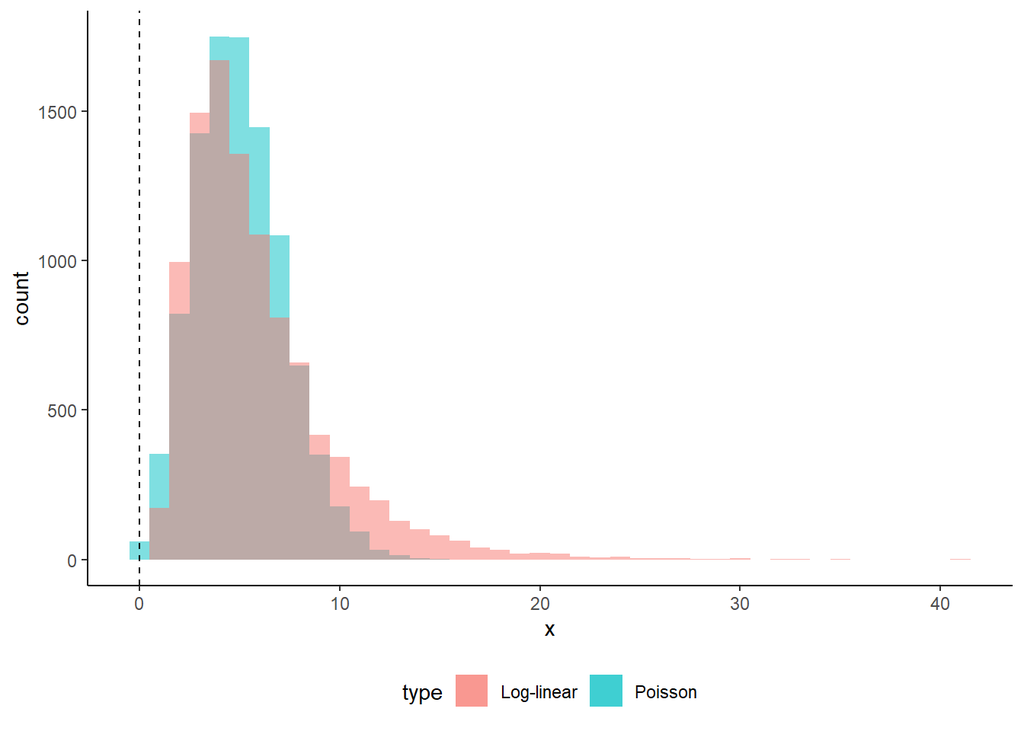

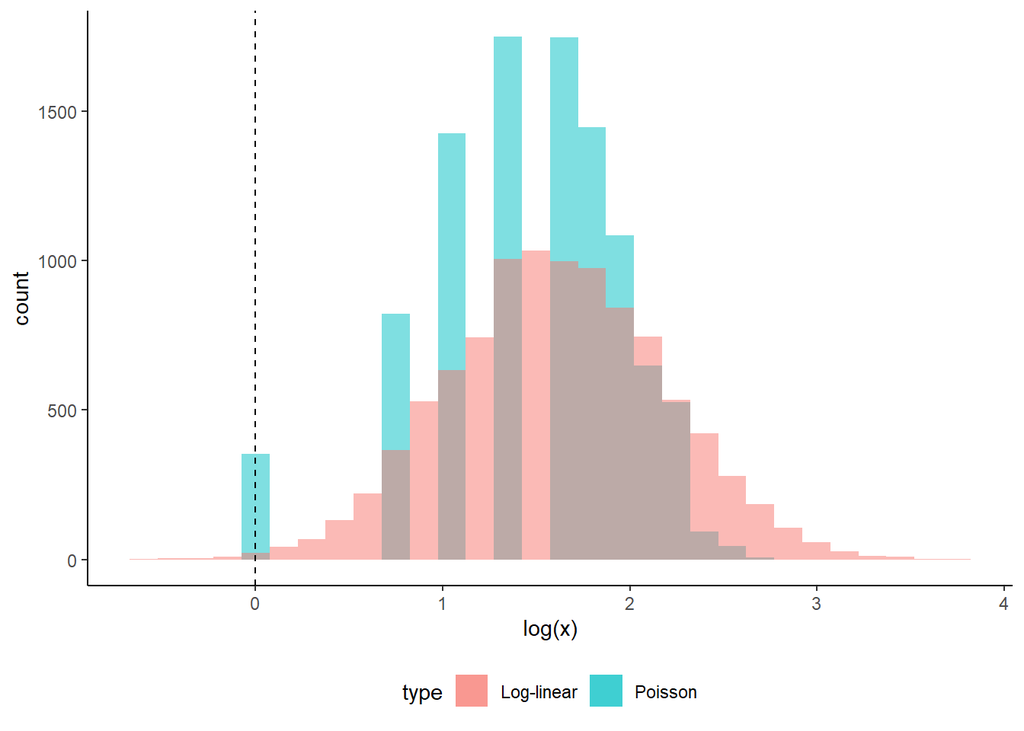

Our data are overdispersed. We will fit a negative binomial model, too. In addition, I am going to fit a log-linear model, a linear rate model, and a linear count model so we can compare them all.

```r
# Negative binomial (from MASS package)
mod_negbin <- glm.nb(ov16_eval_positive ~ offset(log(population)) + mda_rounds, data = dt)
summary(mod_negbin)
```

```
##
## Call:
## glm.nb(formula = ov16_eval_positive ~ offset(log(population)) +
##     mda_rounds, data = dt, init.theta = 12.34987432, link = log)
##
## Deviance Residuals:
##     Min       1Q   Median       3Q      Max
## -2.5792  -0.8075  -0.1032   0.5706   3.9253
##
## Coefficients:
##              Estimate Std. Error z value Pr(>|z|)
## (Intercept) -2.336228   0.034111 -68.489   <2e-16 ***
## mda_rounds  -0.087485   0.008883  -9.849   <2e-16 ***
## ---
## Signif. codes:  0 '***' 0.001 '**' 0.01 '*' 0.05 '.' 0.1 ' ' 1
##
## (Dispersion parameter for Negative Binomial(12.3499) family taken to be 1)
##
##     Null deviance: 461.86  on 349  degrees of freedom
## Residual deviance: 359.96  on 348  degrees of freedom
##   (191 observations deleted due to missingness)
## AIC: 2704.3
##
## Number of Fisher Scoring iterations: 1
##
##
##               Theta:  12.35
##           Std. Err.:  1.27
##
##  2 x log-likelihood:  -2698.301
```

```r
mod_lograte <- glm(log(oo_rate) ~ mda_rounds, data = dt)
summary(mod_lograte)
```

```
##
## Call:
## glm(formula = log(oo_rate) ~ mda_rounds, data = dt)
##
## Deviance Residuals:
##      Min        1Q    Median        3Q       Max
## -0.95561  -0.23751   0.01011   0.22739   1.17535
##
## Coefficients:
##              Estimate Std. Error t value Pr(>|t|)
## (Intercept) -2.375749   0.035900 -66.177   <2e-16 ***
## mda_rounds  -0.089157   0.009224  -9.666   <2e-16 ***
## ---
## Signif. codes:  0 '***' 0.001 '**' 0.01 '*' 0.05 '.' 0.1 ' ' 1
##
## (Dispersion parameter for gaussian family taken to be 0.114908)
##
##     Null deviance: 50.724  on 349  degrees of freedom
## Residual deviance: 39.988  on 348  degrees of freedom
##   (191 observations deleted due to missingness)
## AIC: 239.98
##
## Number of Fisher Scoring iterations: 2
```

```r
# For good measure, make a linear model too
mod_linrate <- glm(oo_rate ~ mda_rounds, data = dt)
mod_lincount <- glm(ov16_eval_positive ~ mda_rounds, data = dt)
```

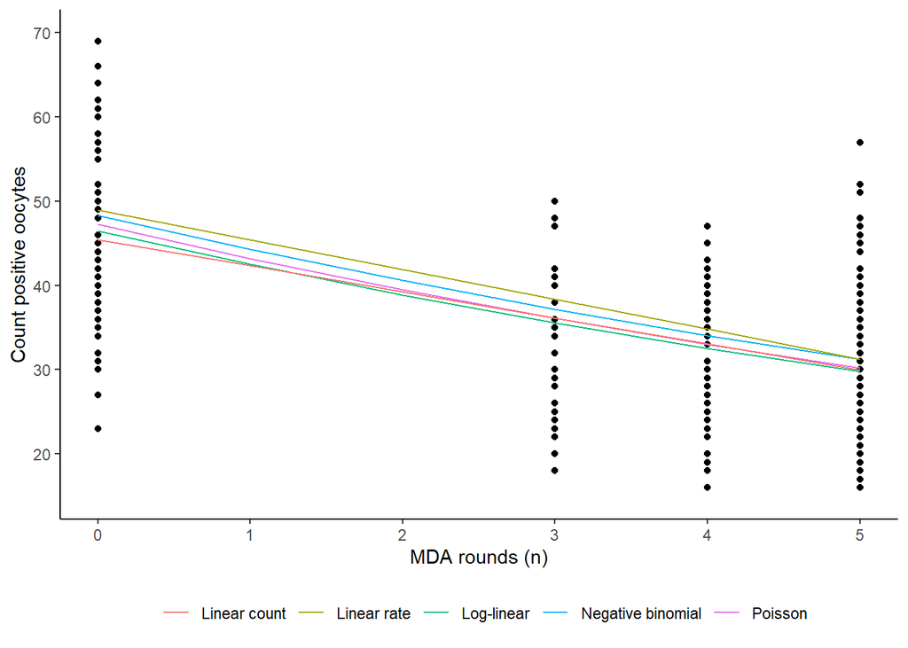

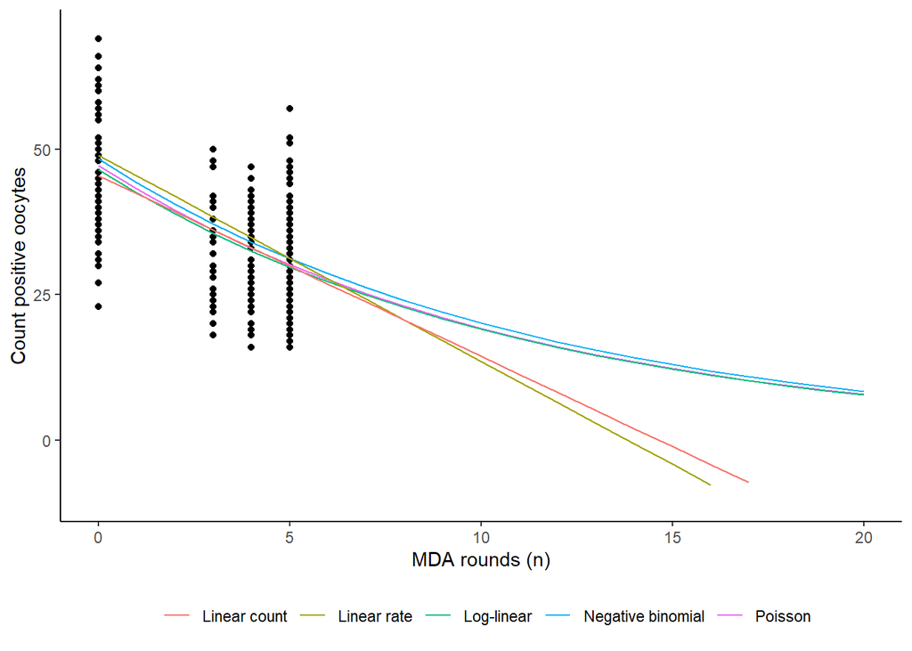

### Individual count models

We don’t have an example of this from the homework 1 data, but think about if your data are on the individual level and your outcome is a count. For example, the number of episodes of diarrhea per child. A poisson model would be appropriate here if you wanted to model episodes as a function of some predictors. You can use child-time the same way:

$$log(\frac{episodes}{time}) \sim X = log(episodes) \sim log(time) + X$$

More complicated time to event models will be covered later!

### Generalized linear mixed models (GLMMs)

We can use the $lme4$ package to run mixed models in the same way.

```r
mixed_pois <- glmer(ov16_eval_positive ~ offset(log(population)) + mda_rounds +
                      (1 | admin2id),
                    data = dt, family = "poisson")
mixed_negbin <- glmer.nb(ov16_eval_positive ~ offset(log(population)) + mda_rounds +
                        (1 | admin2id),
                        data = dt)

summary(mixed_pois)
```

```
## Generalized linear mixed model fit by maximum likelihood (Laplace
##   Approximation) [glmerMod]
##  Family: poisson  ( log )
## Formula: ov16_eval_positive ~ offset(log(population)) + mda_rounds + (1 |
##     admin2id)
##    Data: dt
##
##      AIC      BIC   logLik deviance df.resid
##   3036.3   3047.9  -1515.1   3030.3      347
##
## Scaled residuals:
##     Min      1Q  Median      3Q     Max
## -4.2732 -1.1145 -0.0252  1.1217  9.6448
##
## Random effects:
##  Groups   Name        Variance Std.Dev.
##  admin2id (Intercept) 0.02455  0.1567
## Number of obs: 350, groups:  admin2id, 58
##
## Fixed effects:
##             Estimate Std. Error z value Pr(>|z|)
## (Intercept) -2.31970    0.03634 -63.833   <2e-16 ***
## mda_rounds  -0.09620    0.01030  -9.341   <2e-16 ***
## ---
## Signif. codes:  0 '***' 0.001 '**' 0.01 '*' 0.05 '.' 0.1 ' ' 1
##
## Correlation of Fixed Effects:
##            (Intr)
## mda_rounds -0.771
```

```r
summary(mod_pois)
```

```
##
## Call:
## glm(formula = ov16_eval_positive ~ offset(log(population)) +
##     mda_rounds, family = "poisson", data = dt)
##
## Deviance Residuals:
##     Min       1Q   Median       3Q      Max
## -4.9069  -1.3957  -0.0223   1.2785   6.8831
##
## Coefficients:
##              Estimate Std. Error z value Pr(>|z|)
## (Intercept) -2.359108   0.015893 -148.43   <2e-16 ***
## mda_rounds  -0.089728   0.004333  -20.71   <2e-16 ***
## ---
## Signif. codes:  0 '***' 0.001 '**' 0.01 '*' 0.05 '.' 0.1 ' ' 1
##
## (Dispersion parameter for poisson family taken to be 1)
##
##     Null deviance: 1722.9  on 349  degrees of freedom
## Residual deviance: 1311.6  on 348  degrees of freedom
##   (191 observations deleted due to missingness)
## AIC: 3188.8
##
## Number of Fisher Scoring iterations: 4
```

```r
AIC(mod_pois, mod_negbin, mixed_pois, mixed_negbin)
```

```
##              df      AIC
## mod_pois      2 3188.751
## mod_negbin    3 2704.301
## mixed_pois    3 3036.296
## mixed_negbin  4 2698.117
```

```r
BIC(mod_pois, mod_negbin, mixed_pois, mixed_negbin)
```

```
##              df      BIC
## mod_pois      2 3196.467
## mod_negbin    3 2715.874
## mixed_pois    3 3047.870
## mixed_negbin  4 2713.549
```